# An Introduction to [CHNOSZ](http://www.chnosz.net)

# Equilibration

Above we considered this kind of question: for equal activities of species, what are the affinities of their formation reactions from basis species? Turning the question around, we would like to know: for equal affinities, what are the activities of species? This is the question of equilibration.

Before presenting some examples, it is helpful to know about the limitations of the functions. CHNOSZ does not take account of all possible reactions in the speciation of a system. Instead, it assumes that the total activity of species in the system is set by the activity of *one* basis species. This balanced, or conserved, basis species must be present (with a positive or negative coefficient) in the formation reactions of all species considered.

For a given total activity of the balanced basis species, activities of the species can be found such that the affinities of the formation reactions are all equal. This is an example of metastable equilibrium. With additional constraints, the affinities of the formation reactions are not only equal to each other, but equal to zero. This is total equilibrium. An example of total equilibrium was given above for the PPM buffer. In contrast, models for systems of organic and biomolecules often involve metastable equilibrium constraints.

## Getting from affinity to equilibrium

The `equilibrate()` function in CHNOSZ automatically chooses between two methods for calculating equilibrium. The method based on the Boltzmann equation is fast, but is applicable only to systems where the coefficient on the balanced basis species in each of the formation reactions is one. The reaction-matrix method is slower, but can be applied to systems were the balanced basis species has reaction coefficients other than one.

For more information, see the vignette *Equilibrium in CHNOSZ*.

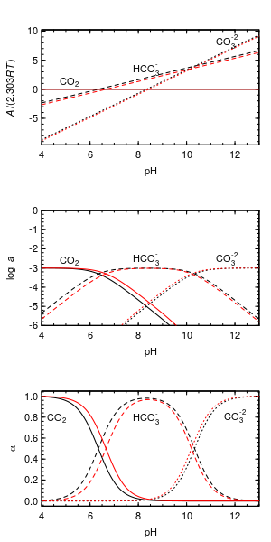

Three views of carbonate speciation: affinity, activity, degree of formation.

The distribution of aqueous carbonate species as a function of pH (a type of Bjerrum plot) is a classic example of an equilibrium calculation. We can begin by plotting the affinities of formation, for equal activities of the species, calculated at 25 °C and 150 °C. Here, CO<sub>2</sub> is in the basis, so it has zero affinity, which is greater than the affinities of HCO<sub>3</sub><sup>-</sup> and CO<sub>3</sub><sup>-2</sup> at low pH. To avoid overplotting the lines, we offset the species labels in the *y* direction using the `dy` argument:

```r
par(mfrow = c(3, 1))
basis("CHNOS+")
species(c("CO2", "HCO3-", "CO3-2"))
a25 <- affinity(pH = c(4, 13))
a150 <- affinity(pH = c(4, 13), T = 150)
diagram(a25, dy = 0.4)
diagram(a150, add = TRUE, col = "red")
```

Now we use `equilibrate()` to calculate the activities of species. Our balancing constraint is that the total activity of C is 10<sup>-3</sup>. This shows a hypothetical metastable equilibrium; we know that for true equilibrium the total activity of C is affected by pH.

```r
e25 <- equilibrate(a25, loga.balance = -3)
e150 <- equilibrate(a150, loga.balance = -3)
diagram(e25, ylim = c(-6, 0), dy = 0.15)
diagram(e150, add = TRUE, col = "red")
```

To display the species distribution, or degree of formation, add `alpha = TRUE` to the argument list:

```r
diagram(e25, alpha = TRUE, dy = -0.25)
diagram(e150, alpha = TRUE, add = TRUE, col = "red")
```

The possible reactions between species are all balanced on 1 C. Therefore, although pH alters the total activity of C, in a system with ideal mixing the total activity of C doesn’t affect the relative activities of these species.

See `demo(solubility)` for calculations of the total activity of C in this ideal system; uncomment a line in the demo to run calculations for CO<sub>2</sub> instead of calcite.

## Groups of species

Sometimes it is helpful to look at the summed activities of species as groups on species distribution diagrams. The `groups` argument of `diagram()` can be used to sum the activities of species.

To demonstrate this feature, let’s consider the distribution of carbon among organic and inorganic species in the hydrothermal mixing scenario described by Shock and Schulte (1998). First we define the basis and add two inorganic species. The `index.return = TRUE` argument tells `info()` to return the index (number) of the species in the current species definition; these indices are saved for use below:

Shock EL, Schulte MD. 1998. Organic synthesis during fluid mixing in hydrothermal systems. *Journal of Geophysical Research* **103**(E12): 28513–28527. doi: 10.1029/98JE02142

```r
basis("CHNOS+")
ii <- species(c("CO2", "HCO3-"), index.return = TRUE)
```

Next, we add each group of organic species: C<sub>1</sub>–C<sub>8</sub> alcohols, C<sub>3</sub>–C<sub>8</sub> ketones, C<sub>2</sub>–C<sub>12</sub> carboxylic acids and their corresponding anions, and C<sub>2</sub>–C<sub>8</sub> alkenes. To do this, we provide `info()` with a set of `ispecies` values that identify these species. In the database, the species in each group are ordered by carbon number, so we construct a sequence from the starting to ending `ispecies` for each group using R’s `seq()` function, wrapped by the `seq2()` function we write here to make the code shorter:

```r
seq2 <- function(x) seq(x[1], x[2])
ia <- species(seq2(info(c("methanol", "octanol"))), index.return = TRUE)
ik <- species(seq2(info(c("acetone", "2-octanone"))), index.return = TRUE)
ic <- species(seq2(info(c("acetic acid","n-dodecanoic acid"))),index.return=TRUE)
ica <- species(seq2(info(c("acetate", "n-dodecanoate"))), index.return = TRUE)
ie <- species(seq2(info(c("ethylene", "octene"))), index.return = TRUE)
```

Now we read two data files that contain values of log*f*<sub>O<sub>2</sub></sub> and pH as a function of temperature, digitized from Figure 5 of Shock and Schulte (1998). These values were calculated using a speciation and mixing model that is not available in CHNOSZ; however, we can use these intermediate values as input to the “downstream” calculations that are available in CHNOSZ. Because of the noise introduced by digitization of the figure, we smooth the data using R’s `smooth.spline()`; the lower *T* limit reflects the absence of data below this temperature in the figure for log*f*<sub>O<sub>2</sub></sub>.

The specific values are for calculations with vent fluids initially set by the fayalite-magnetite-quartz buffer minus 1/2 log*f*<sub>O<sub>2</sub></sub> (FMQ - 1/2).

```r
O2dat <- read.csv(system.file(
  "extdata/cpetc/SS98_Fig5a.csv", package = "CHNOSZ"))
pHdat <- read.csv(system.file(
  "extdata/cpetc/SS98_Fig5b.csv", package = "CHNOSZ"))
T <- seq(8, 350)
O2 <- predict(smooth.spline(O2dat$T, O2dat$logfO2), T)$y
pH <- predict(smooth.spline(pHdat$T, pHdat$pH), T)$y
```

We are ready to calculate affinities and equilibrium activities of the species. This calculation utilizes the transect mode of `affinity()` (see above). The call to `equilibrate()` runs with the default balance (in this case, CO<sub>2</sub>), with a log activity set to -2.5.

Actually, the total concentration of carbon depends on the mixing ratio, ranging from about 10<sup>-2.2</sup> (seawater) to 10<sup>-2.6</sup> (vent fluid). A setting to vary the activity of the balanced basis species is not yet implemented in CHNOSZ, so a single value is used here.

```r
a <- affinity(T = T, O2 = O2, pH = pH)
e <- equilibrate(a, loga.balance = -2.5)
```

At last we come to the diagram. The groups are identified by the current species numbers in a list; the elements of the list are given names that will appear on the diagram. When summing the activities of species in the groups, each activity is multiplied first by the balance coefficient on that species. Therefore, the total activity is that of a basis species (or of an element that is present only in that basis species, like carbon in this example).

[figure not shown]

```r
par(mfrow = c(1, 3))
groups <- list(inorganic = ii, alcohols = ia, ketones = ik,
               `carboxylic acids` = c(ic, ica), alkenes = ie)
diagram(e, alpha = TRUE, groups = groups, col = 1:5)
# plot only alcohols
```

That makes a diagram that is similar to Figure 6b of Shock and Schulte (1998). It is also possible to plot the distribution of species within individual groups, such as alcohols and ketones. We do this by setting the names and line types for the *other* species to values that prevent them from being plotted:

Some differences from the original diagrams could be caused by the sensitivity of the calculations to log*f*<sub>O<sub>2</sub></sub>, for which the values we use here may carry artifacts introduced by digitization of their plot.

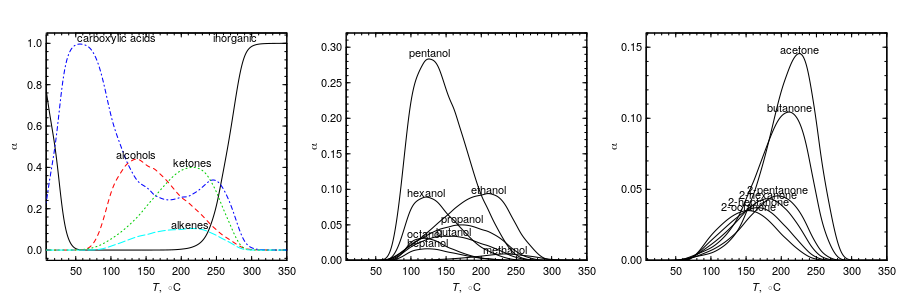

Distribution of inorganic and groups of organic species (left plot) and of alcohols and ketones (middle and right plots) as a function of *T*, pH, and log*f*<sub>O<sub>2</sub></sub>.

```r
# plot only alcohols
names <- within(species(), name[-ia] <- "")$name
lty <- ifelse(names == "", 0, 1)
diagram(e, alpha = TRUE, ylim = c(0, 0.32), lty = lty, names = names)
# plot only ketones
names <- within(species(), name[-ik] <- "")$name
lty <- ifelse(names == "", 0, 1)
diagram(e, alpha = TRUE, ylim = c(0, 0.16), lty = lty, names = names)
```

## Balancing differently

How about the choice between balancing constraints? Be default, `equilibrate()` and `diagram()` balance reactions on the first basis species that is present in each of the species of interest. Let’s look at some amino acids in a hypothetical metastable equilibrium. This calculation is loosely based on one described by Shock (1990) for five amino acids. Here we include 20 proteinogenic amino acids, whose names are returned by `aminoacids("")`. We use `ZC.col()` to generate colors based on the average oxidation state of carbon of the amino acids (red and blue for relatively reduced and oxidized).

Shock EL. 1990. Do amino acids equilibrate in hydrothermal fluids? *Geochimica et Cosmochimica Acta* **54**(4): 1185–1189. doi: 10.1016/0016-7037(90)90450-Y

```r
basis("CHNOS")
basis("CO2", "gas")
swap.basis("NH3", "N2")
species(aminoacids(""))
a <- affinity(O2 = c(-50, -25, 200), CO2 = c(-10, 15, 200), T = 250, P = 265)
aa.ZC <- ZC(info(aminoacids("")))
col <- ZC.col(aa.ZC)
```

To make plots using different balance constraints, let’s write a function that sets the `balance` argument of `diagram()` and adds a title to the plot. The first plot is the most similar to Figure 4 of Shock (1990), except for the absence of alanine (probably due to different thermodynamic data) and the presence of some other amino acids. There, we set `balance = 1`, which indicates that moles of species are conserved; this is equivalent to balancing on the amino acid backbone. In the remaining plots, the balance is set to each of the basis species in turn (except for O<sub>2</sub>), then on volume. `expr.species()` together with R’s `substitute()` is used to make titles that include formatted chemical formulas:

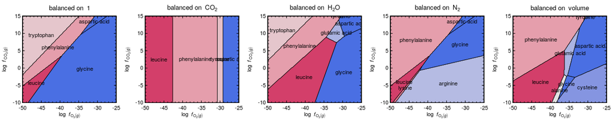

Plots of maximum affinity at 250 °C and 265 bar using different reaction balances for 20 amino acids.

```r
aafun <- function(balance) {
  diagram(a, balance = balance, fill = col)
  blab <- expr.species(balance)
  title(main = substitute("balanced on" ~ b, list(b = blab)))
}
par(mfrow = c(1, 5))
lapply(c("1", "CO2", "H2O", "N2", "volume"), aafun)
```

There are some broad similarities—increasing log*f*<sub>O<sub>2</sub></sub> favors more oxidized amino acids—but also substantial differences. It is interesting that there is more “going on” in the middle part of the diagram showing volume conservation.

*Caveat lector*. These plots demonstrate some possibilities in CHNOSZ and are not necessarily realistic portrayals of this system. It does seem odd to balance on a fugacious component like O<sub>2</sub> or H<sub>2</sub>O. Unlike different choices of basis species, which are thermodynamically equivalent (see above), the choice of balance reflects extra-thermodynamic factors. For instance, the widespread rule of thumb for balancing mineral reactions on a chemical component is unrealistic for processes where volume is conserved (Merino and Dewers, 1998). While choosing an inappropriate balance leads to infeasible models, consideration of the different possibilities might give insight into the conditions affecting the dynamics of some systems.

Merino E, Dewers T. 1998. Implications of replacement for reaction–transport modeling. *Journal of Hydrology* **209**(1–4): 137–146. doi: 10.1016/S0022-1694(98)00150-4

# Activity coefficients

For calculating activity coefficients of charged species, `nonideal()` uses the extended Debye–Hückel equation as parameterized by Helgeson et al. (1981) for NaCl-dominated solutions to high pressure and temperature, or optionally using parameters described in Chapter 3 of Alberty (2003), which are applicable to relatively low-temperature biochemical reactions. The activity coefficients are calculated as a function of ionic strength (*I*), temperature, and charge of each species, without any other species-specific parameters. Using the default `Helgeson` method, the extended term parameter (“B-dot”) is derived from data of Helgeson (1969) and Helgeson et al. (1981), and extrapolations of Manning et al. (2013).

Helgeson HC, Kirkham DH, Flowers GC. 1981. Theoretical prediction of the thermodynamic behavior of aqueous electrolytes at high pressures and temperatures: IV. Calculation of activity coefficients, osmotic coefficients, and apparent molal and standard and relative partial molal properties to 600°C and 5 Kb. *American Journal of Science* **281**(10): 1249–1516. doi: 10.2475/ajs.281.10.1249

Alberty RA. 2003. *Thermodynamics of Biochemical Reactions*. Hoboken, New Jersey: Wiley-Interscience. Available at http://www.worldcat.org/oclc/51242181.

Helgeson HC. 1969. Thermodynamics of hydrothermal systems at elevated temperatures and pressures. *American Journal of Science* **267**(7): 729–804. doi: 10.2475/ajs.267.7.729

Manning CE, Shock EL, Sverjensky DA. 2013. The chemistry of carbon in aqueous fluids at crustal and upper-mantle conditions: Experimental and theoretical constraints. *Reviews in Mineralogy and Geochemistry* **75**(1): 109–148. doi: 10.2138/rmg.2013.75.5

## Transformation of variables

Following the main workflow of CHNOSZ, `nonideal()` normally does not need to be used directly. Intead, invoke the calculations by setting the `IS` argument in `subcrt()` or `affinity()`. There are a few things to remember when using activity coefficients:

- H<sup>+</sup> is assumed to behave ideally, so its activity coefficient is 1 for any ionic strength. You can calculate activity coefficients of H<sup>+</sup> by setting `thermo$opt$ideal.H <<- FALSE`.
- Using `subcrt()` with `IS` not equal to zero, calculated values of `G` are the **adjusted** Gibbs energy at specified ionic strength (denoted by Δ*G*°(*I*); Alberty, 1996).

  Alberty RA. 1996. Recommendations for nomenclature and tables in biochemical thermodynamics. *European Journal of Biochemistry* **240**(1): 1–14. Blackwell Science Ltd. doi: 10.1111/j.1432-1033.1996.0001h.x
- Using `subcrt()` with `IS` not equal to zero, values in the `logact` argument stand for **log molality** of aqueous species in affinity calculations.
- Using `affinity()` with `IS` not equal to zero, the following values stand for **log molality** of aqueous species:
  - values of `logact` set by `basis()`;
  - values of `logact` set by `species()`.
- Using `equilibrate()` on the output of affinity calculated with `IS` not equal to zero, the following values stand for **log molality** of aqueous species:
  - the value of `loga.balance` used by `equilibrate()` (i.e., logarithm of total molality of the balancing basis species);
  - values of `loga.equil` returned by `equilibrate()`.

In other words, the activation of activity coefficients effects a transformation from activity to molality in the main workflow. A simple but comprehensive series of calculations demonstrating these tranformations is in `tests/testthat/test-logmolality.R`.

Because it is not possible to dynamically change the names of arguments in the functions, the user should be aware of the transformations mentioned above. However, the labels on diagrams *can* be automatically adjusted; accordingly, activities of aqueous species are relabeled as molalities by `diagram()` when `IS` is used in the calculation of `affinity()`.

## Biochemical example

For the following calculations, we change the nonideality method to `Alberty`; this is a simpler formulation with parameters that are suitable for biochemical species at relatively low temperatures:

```r
oldnon <- nonideal("Alberty")
```

```
## nonideal: setting nonideal option to use Alberty method
```

Let’s take a look at calculated activity coefficients at two temperatures and their effect on the standard Gibbs energies of formation (Δ*G*°<sub>*f*</sub>) of species with different charge:

```r
subcrt(c("MgATP-2", "MgHATP-", "MgH2ATP"),
       T = c(25, 100), IS = c(0, 0.25), property = "G")$out
```

```
## subcrt: 3 species at 2 values of T and P (wet)
```

```
## nonideal: calculated activity coefficients for 2 species (Alberty method)
```

```
## $`MgATP-2`
##     T       P       G    loggam   IS
## 1  25 1.00000 -773609  0.000000 0.00
## 2 100 1.01322 -780416 -0.656185 0.25
##
## $`MgHATP-`
##     T       P       G    loggam   IS
## 1  25 1.00000 -780994  0.000000 0.00
## 2 100 1.01322 -789617 -0.164046 0.25
##
## $MgH2ATP
##     T       P       G
## 1  25 1.00000 -786200
## 2 100 1.01322 -795012
```

The logarithms of the activity coefficients (`loggam`) are more negative for the higher-charged species, as well as at higher temperature, and have a stabilizing effect. That is, the adjusted Gibbs energies at *I* > 0 are less than the standard Gibbs energies at *I* = 0.

We can use these calculations to make some speciation plots, similar to Figures 1.2–1.5 in Alberty (2003). These figures show the distribution of differently charged species of adenosine triphosphate (ATP) as a function of pH, and the average number of H<sup>+</sup> and Mg<sup>+2</sup> bound to ATP in solution as a function of pH or pMg (-log*a*<sub>Mg<sup>+2</sup></sub>).

Use `info()` to see what ATP species are available. The sources of high-temperature thermodynamic data for these species are two papers by LaRowe and Helgeson (2006a; 2006b).

LaRowe DE, Helgeson HC. 2006a. Biomolecules in hydrothermal systems: Calculation of the standard molal thermodynamic properties of nucleic-acid bases, nucleosides, and nucleotides at elevated temperatures and pressures. *Geochimica et Cosmochimica Acta* **70**(18): 4680–4724. doi: 10.1016/j.gca.2006.04.010

LaRowe DE, Helgeson HC. 2006b. The energetics of metabolism in hydrothermal systems: Calculation of the standard molal thermodynamic properties of magnesium-complexed adenosine nucleotides and NAD and NADP at elevated temperatures and pressures. *Thermochimica Acta* **448**(2): 82–106. doi: 10.1016/j.tca.2006.06.008

```r
info(" ATP")
```

```
## info.approx: ' ATP' is ambiguous; has approximate matches to 14 species:
```

```
##  [1] "ATP-4"    "HATP-3"   "H2ATP-2"  "H3ATP-"   "H4ATP"    "dATP-4"
##  [7] "dHATP-3"  "dH2ATP-2" "dH3ATP-"  "dH4ATP"   "MgATP-2"  "MgHATP-"
## [13] "MgH2ATP"  "Mg2ATP"
```

The plots for this system in Alberty’s book were made for *I* = 0.25 M and *T* = 25 °C. As a demonstration of CHNOSZ’s capabilities, we can assign a temperature of 100 °C.

```r
T <- 100
```

To make the code more readable, commands for plotting titles and legends are not shown. All of the commands are available in the source of this document.

```r
basis("MgCHNOPS+")
species(c("ATP-4", "HATP-3", "H2ATP-2", "H3ATP-", "H4ATP"))
a <- affinity(pH = c(3, 9), T = T)
e <- equilibrate(a)
d <- diagram(e, alpha = TRUE, tplot = FALSE)
```

Note that we have saved the numeric results of `diagram()`, i.e. the degrees of formation of the species (α). With that, we can calculate and plot the average number of protons bound per ATP molecule. To do so, we use R’s `rbind()` and `do.call()` to turn `alpha` into a matrix, then multiply by the number of protons bound to each species, and sum the columns to get the total (i.e. average proton number, *N*<sub>H<sup>+</sup></sub>):

```r
alphas <- do.call(rbind, d$plotvals)
nH <- alphas * 0:4
Hlab <- substitute(italic(N)[H^`+`])
plot(a$vals[[1]], colSums(nH), type = "l", xlab = "pH", ylab=Hlab, lty=2, col=2)
```

Adding the `IS` argument to `affinity()`, we can now plot *N*<sub>H<sup>+</sup></sub> at the given ionic strength. Here we set `plot.it = FALSE` in `diagram()` because we use the computed α to make our own plot. This is similar to Figure 1.3 of Alberty (2003), but at higher temperature:

```r
a <- affinity(pH = c(3, 9), IS = 0.25, T = T)
e <- equilibrate(a)
d <- diagram(e, alpha = TRUE, plot.it = FALSE)
alphas <- do.call(rbind, d$plotvals)
nH <- alphas * 0:4
lines(a$vals[[1]], colSums(nH))
```

Next, we add the Mg<sup>+2</sup>-complexed ATP species:

```r
species(c("MgATP-2", "MgHATP-", "MgH2ATP", "Mg2ATP"))
```

Here is a function to calculate and plot *N*<sub>H<sup>+</sup></sub> for a given pMg:

```r
Hplot <- function(pMg, IS = 0.25) {
  basis("Mg+2", -pMg)
  a <- affinity(pH = c(3, 9), IS = IS, T = T)
  e <- equilibrate(a)
  d <- diagram(e, alpha = TRUE, plot.it = FALSE)
  alphas <- do.call(rbind, d$plotvals)
  NH <- alphas * c(0:4, 0, 1, 2, 0)
  lines(a$vals[[1]], colSums(NH), lty = 7 - pMg, col = 7 - pMg)
}
```

With that function in hand, we plot the lines corresponding to pMg = 2 to 6. This is similar to Figure 1.4 of Alberty (2003):

```r
plot(c(3, 9), c(0, 2), type = "n", xlab = "pH", ylab = Hlab)
lapply(2:6, Hplot)
```

The next function calculates and plots the average number of Mg<sup>+2</sup> bound to ATP (*N*<sub>Mg<sup>+2</sup></sub>) for a given pH. Here we multiply `alpha` by the number of Mg<sup>+2</sup> in each species, and negate log*a*<sub>Mg<sup>+2</sup></sub> (the variable used in `affinity()`) to get pMg:

```r
Mgplot <- function(pH, IS = 0.25) {
  basis("pH", pH)
  a <- affinity(`Mg+2` = c(-2, -7), IS = IS, T = T)
  e <- equilibrate(a)
  d <- diagram(e, alpha = TRUE, plot.it = FALSE)
  alphas <- do.call(rbind, d$plotvals)
  NMg <- alphas * species()$`Mg+`
  lines(-a$vals[[1]], colSums(NMg), lty = 10 - pH, col = 10 - pH)
}
```

Using that function, we plot the lines corresponding to pH = 3 to 9. This is similar to Figure 1.5 of Alberty (2003):

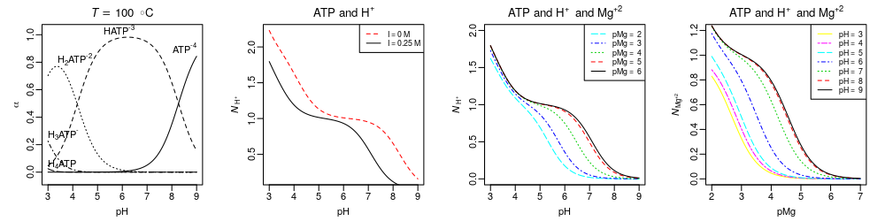

Binding of H<sup>+</sup> and Mg<sup>+2</sup> to ATP at 100 °C and *I* = 0 M (first plot) or *I* = 0.25 M (third and fourth plots).

```r
Mglab <- substitute(italic(N)[Mg^`+2`])
plot(c(2, 7), c(0, 1.2), type = "n", xlab = "pMg", ylab = Mglab)
lapply(3:9, Mgplot)
```

We have calculated the distribution of ATP species and average binding number of H<sup>+</sup> and Mg<sup>+2</sup> for given pH, pMg, ionic strength, and temperature. Accounting for the distribution of chemical species lends itself to thermodynamic models for reactions between reactants that have multiple ionized and complexed states. In contrast, Alberty (2003) and others propose models for biochemical reactions where the ionized and complexed species are combined into a single representation. Those models invoke Legendre-transformed thermodynamic properties, such as transformed Gibbs energies that are tabulated for specified pH, pMg, and ionic strength. Although the conceptual pathways are different, the two approaches lead to equivalent results concerning the energetics of the overall reactions and the conditions for equilibrium (Sabatini et al., 2012). The example here shows how the required calculations can be performed at the species level using conventional standard Gibbs energies for species referenced to infinite dilution (zero ionic strength). The effects of ionic strength are modeled “on the fly” in CHNOSZ by setting the `IS` argument in `subcrt()` or `affinity()` to invoke the nonideality model on top of the standard Gibbs energies of species.

Sabatini A, Vacca A, Iotti S. 2012. Balanced biochemical reactions: A new approach to unify chemical and biochemical thermodynamics. *PLoS ONE* **7**(1): e29529. doi: 10.1371/journal.pone.0029529

Now that we’re finished, we can reset the nonideality method to the default. (This really isn’t needed here, because there aren’t any nonideality calculations below):

```r
nonideal(oldnon)
```

```
## nonideal: setting nonideal option to use Helgeson method
```

# Proteins

Proteins in CHNOSZ are handled a little bit differently from other species. Amino acid group additivity is used to obtain the thermodynamic properties of proteins. Therefore, CHNOSZ has a data file with amino acid compositions of selected proteins, as well as functions for reading and downloading amino acid sequence data.

When proteins in CHNOSZ are identified by name, they include an underscore, such as in `LYSC_CHICK` (chicken lysozyme C). Use `pinfo()` to search for one or more proteins by name; multiple proteins from the same organism can be specified using the `organism` argument. The name search returns the rownumbers of `thermo$protein` (i.e. `iprotein`, the protein indices). Supply those protein indices to `pinfo()` to get the amino acid compositions:

```r
p1 <- pinfo("LYSC_CHICK")
p2 <- pinfo(c("SHH", "OLIG2"), "HUMAN")
pinfo(c(p1, p2))
```

```
##     protein organism     ref    abbrv chains Ala Cys Asp Glu Phe Gly His Ile
## 6      LYSC    CHICK UniProt   P00698      1  12   8   7   2   3  12   1   6
## 452     SHH    HUMAN UniProt Q15465.N      1  14   3  10  14   5  16   6   7
## 453   OLIG2    HUMAN UniProt   Q13516      1  51   5  10  10   5  35  18   7
##     Lys Leu Met Asn Pro Gln Arg Ser Thr Val Trp Tyr
## 6     6   8   2  14   2   3  11  10   7   6   6   3
## 452  15  11   3   8   7   3  13  12   8   9   3   7
## 453  14  29  11   4  31   5  13  50  11  10   1   3
```

The length and chemical formula of one or more proteins are returned by `protein.length()` and `protein.formula()`. We can calculate the formula of the protein, and the per-residue formula, and show that both have the same average oxidation state of carbon:

These functions accept either names or the protein indices (`iprotein`).

```r
pl <- protein.length("LYSC_CHICK")
pf <- protein.formula("LYSC_CHICK")
list(length = pl, protein = pf, residue = pf / pl,
     ZC_protein = ZC(pf), ZC_residue = ZC(pf / pl))
```

```
## $length
## [1] 129
##
## $protein
##              C   H   N   O  S
## LYSC_CHICK 613 959 193 185 10
##
## $residue
##                  C       H       N       O         S
## LYSC_CHICK 4.75194 7.43411 1.49612 1.43411 0.0775194
##
## $ZC_protein
## [1] 0.0163132
##
## $ZC_residue
## [1] 0.0163132
```

## Group additivity and ionization

The group additivity calculations for proteins are based on equations and data from Amend and Helgeson (2000), Dick et al. (2006), and LaRowe and Dick (2012). There are two major options for the calculations: whether to calculate properties for crystalline or aqueous groups, and, for the latter, whether to model the ionization of the sidechain and terminal groups as a function of pH (and *T* and *P*). By default, additivity of aqueous groups is used, but the ionization calculations are not available in `subcrt()`:

Amend JP, Helgeson HC. 2000. Calculation of the standard molal thermodynamic properties of aqueous biomolecules at elevated temperatures and pressures. II. Unfolded proteins. *Biophysical Chemistry* **84**(2): 105–136. doi: 10.1016/S0301-4622(00)00116-2

Dick JM, LaRowe DE, Helgeson HC. 2006. Temperature, pressure, and electrochemical constraints on protein speciation: Group additivity calculation of the standard molal thermodynamic properties of ionized unfolded proteins. *Biogeosciences* **3**(3): 311–336. doi: 10.5194/bg-3-311-2006

LaRowe DE, Dick JM. 2012. Calculation of the standard molal thermodynamic properties of crystalline peptides. *Geochimica et Cosmochimica Acta* **80**: 70–91. doi: 10.1016/j.gca.2011.11.041

```r
subcrt("LYSC_CHICK")$out[[1]][1:6, ]
```

```
##        T       P      rho    logK        G         H       S       V      Cp
## 1   0.01 1.00000 0.999829 3217.68 -4021765 -10423733 3685.29 10049.2 4409.32
## 2  25.00 1.00000 0.997061 3019.80 -4119738 -10283083 4176.74 10421.0 6415.52
## 3  50.00 1.00000 0.988030 2861.40 -4230972 -10113250 4723.39 10600.2 7073.98
## 4  75.00 1.00000 0.974864 2734.31 -4355838  -9932209 5262.87 10708.1 7376.58
## 5 100.00 1.01322 0.958393 2632.00 -4493930  -9745475 5780.77 10782.9 7548.44
## 6 125.00 2.32014 0.939073 2549.29 -4644330  -9554920 6274.14 10840.9 7665.20
```

Let’s compare experimental values of heat capacity of four proteins, from Privalov and Makhatadze (1990), with those calculated using group additivity. After dividing Privalov and Makhatadze’s experimental values by the lengths of the proteins to get per-residue values, we convert those to calories, then plot them.

Privalov PL, Makhatadze GI. 1990. Heat capacity of proteins. II. Partial molar heat capacity of the unfolded polypeptide chain of proteins: Protein unfolding effects. *Journal of Molecular Biology* **213**(2): 385–391. doi: 10.1016/S0022-2836(05)80198-6

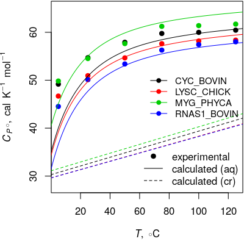

The heat capacity calculated by group additivity closely approximates experimental values for aqueous proteins. For a related figure showing the effects of ionization in the calculations, see ?ionize.aa.

```r
PM90 <- read.csv(system.file("extdata/cpetc/PM90.csv", package = "CHNOSZ"))
plength <- protein.length(colnames(PM90)[2:5])
Cp_expt <- t(t(PM90[, 2:5]) / plength)
matplot(PM90[, 1], convert(Cp_expt, "cal"), type = "p", pch = 19,
        xlab = axis.label("T"), ylab = axis.label("Cp0"), ylim = c(28, 65))
```

The loop calculates the properties of each protein using group additivity with aqueous or crystalline groups, then plots the per-residue values.

```r
for(i in 1:4) {
  pname <- colnames(Cp_expt)[i]
  aq <- subcrt(pname, "aq", T = seq(0, 150))$out[[1]]
  cr <- subcrt(pname, "cr", T = seq(0, 150))$out[[1]]
  lines(aq$T, aq$Cp / plength[i], col = i)
  lines(cr$T, cr$Cp / plength[i], col = i, lty = 2)
}
legend("right", legend = colnames(Cp_expt),
       col = 1:4, pch = 19, lty = 1, bty = "n", cex = 0.9)
legend("bottomright", legend = c("experimental", "calculated (aq)",
       "calculated (cr)"), lty = c(NA, 1, 2), pch = c(19, NA, NA), bty = "n")
```

Although `subcrt()` has no provision for protein ionization, the properties of ionization can be calculated via `affinity()`, which calls `ionize.aa()` if a charged species is in the basis. The following plot shows the calculated affinity of reaction between nonionized proteins and their ionized forms as a function of pH. Charged and uncharged sets of basis species are used to to activate and suppress the ionization calculations. The calculation of affinity for the ionized proteins returns multiple values (as a function of pH), but there is only one value of affinity returned for the nonionized proteins, so we need to use R’s `as.numeric()` to avoid subtracting nonconformable arrays:

Whether to calculate properties using aqueous or crystalline groups is determined by the value of `thermo$opt$state`; if it is changed from its default of `aq` to `cr`, no ionization is possible.

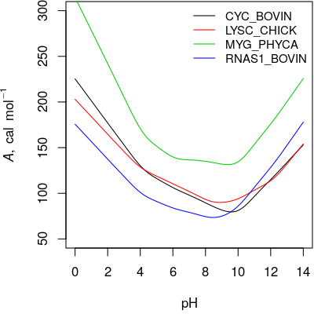

Affinity of ionization of proteins. See demo(ionize) for ionization properties calculated as a function of temperature and pH.

```r
ip <- pinfo(c("CYC_BOVIN", "LYSC_CHICK", "MYG_PHYCA", "RNAS1_BOVIN"))
basis("CHNOS+")
a_ion <- affinity(pH = c(0, 14), iprotein = ip)
basis("CHNOS")
a_nonion <- affinity(iprotein = ip)
plot(c(0, 14), c(50, 300), xlab = "pH", ylab = axis.label("A"), type = "n")
for(i in 1:4) {
  A_ion <- as.numeric(a_ion$values[[i]])
  A_nonion <- as.numeric(a_nonion$values[[i]])
  lines(a_ion$vals[[1]], A_ion - A_nonion, col=i)
}
legend("topright", legend = a_ion$species$name,
       col = 1:4, lty = 1, bty = "n", cex = 0.9)
```

The affinity is always positive, showing the strong energetic drive for ionization of proteins in aqueous solution. The degrees of ionization of amino and carboxyl groups increase at low and high pH, respectively, giving rise to the U-shaped lines.

There, we used the indices returned by `pinfo()` in the `iprotein` argument of `affinity()` to specify the proteins in the calculation. That approach utilizes some optimizations that can be realized due to group additivity, and is useful for calculations involving many proteins. An alternative, but slower, approach is to identify the proteins to `species()`; this produces results that are equivalent to using the `iprotein` argument:

```r
species(c("CYC_BOVIN", "LYSC_CHICK", "MYG_PHYCA", "RNAS1_BOVIN"))
a_nonion_species <- affinity()
```

```r
unlist(a_nonion_species$values)
```

```
##      3590      3589      3593      3595
## -122.5026 -700.5444  -50.6508 -731.8601
```

The `ispecies` index (top) refers to the rownumber of `thermo$species`; that is distinct from the `iprotein` index (bottom, printed as negative integers), which refers to the rownumber of `thermo$protein`.

```r
unlist(a_nonion$values)
```

```
##        -5        -6        -7        -9
## -122.5026 -700.5444  -50.6508 -731.8601
```

## Compositional analysis

Functions in CHNOSZ make it easy to get the chemical formulas of proteins from their amino acid compositions. Calculations based on the formulas, such as the average oxidation state of carbon (*Z*<sub>C</sub>), and the coefficients of basis species in formation reactions, are also available.

Let’s compare the *Z*<sub>C</sub> of Rubisco with optimal growth temperature of organisms, as shown in Figure 6a of Dick (2014). First we read a CSV file with the IDs of the proteins and the optimal growth temperatures (*T*<sub>opt</sub>); the midpoint of the range of *T*<sub>opt</sub> is used for plotting. Then we use `read.fasta()` to read a FASTA file holding the amino acid sequences of the proteins; the function returns a data frame with the amino acid counts. To put the proteins in the right order, the IDs in the CSV file are matched to the names of the proteins in the FASTA file. Then, we calculate *Z*<sub>C</sub> from the formulas of the proteins. Next, point symbols are assigned according to domain (Archaea, Bacteria, Eukaryota); numbers inside the symbols show the ordering of *T*<sub>opt</sub> in three temperature ranges (0–35 °C, 37.5–60 °C, and 65–100 °C).

Dick JM. 2014. Average oxidation state of carbon in proteins. *Journal of the Royal Society Interface* **11**: 20131095. doi: 10.1098/rsif.2013.1095

[figure not shown]

Average oxidation state of carbon in Rubisco compared with optimal growth temperature of organisms. **This is an interactive image.** Move the mouse over the points to show the names of the organisms, and click to open a reference in a new window. (Made with [**RSVGTipsDevice**](https://cran.r-project.org/package=RSVGTipsDevice) using code that can be found in the source of this document.)

```r
datfile <- system.file("extdata/cpetc/rubisco.csv", package = "CHNOSZ")
fastafile <- system.file("extdata/fasta/rubisco.fasta", package = "CHNOSZ")
dat <- read.csv(datfile)
aa <- read.fasta(fastafile)
Topt <- (dat$T1 + dat$T2) / 2
idat <- match(dat$ID, substr(aa$protein, 4, 9))
aa <- aa[idat, ]
ZC <- ZC(protein.formula(aa))
pch <- match(dat$domain, c("E", "B", "A")) - 1
col <- match(dat$domain, c("A", "B", "E")) + 1
plot(Topt, ZC, pch = pch, cex = 2, col = col,
     xlab = expression(list(italic(T)[opt], degree*C)),
     ylab = expression(italic(Z)[C]))
text(Topt, ZC, rep(1:9, 3), cex = 0.8)
abline(v = c(36, 63), lty = 2, col = "grey")
legend("topright", legend = c("Archaea", "Bacteria", "Eukaryota"),
       pch = c(2, 1, 0), col = 2:4, pt.cex = 2)
```

Let’s look at the different ways of representing the chemical compositions of the proteins. `protein.basis()` returns the stoichiometry for the formation reaction of each proteins. Dividing by `protein.length()` gives the per-residue reaction coefficients (*n*̅). Using the set of basis species we have seen before (CO<sub>2</sub>, NH<sub>3</sub>, H<sub>2</sub>S, H<sub>2</sub>O, O<sub>2</sub>) there is a noticeable correlation between *n*̅<sub>O<sub>2</sub></sub> and *Z*<sub>C</sub>, but even more so between *n*̅<sub>H<sub>2</sub>O</sub> and *Z*<sub>C</sub> (shown in the plots on the left). The `QEC` keyword to `basis()` loads basis species including three amino acids (glutamine, glutamic acid, cysteine, H<sub>2</sub>O, O<sub>2</sub>). This basis strengthens the relationship between *Z*<sub>C</sub> and *n*̅<sub>O<sub>2</sub></sub>, but weakens that between *Z*<sub>C</sub> and *n*̅<sub>H<sub>2</sub>O</sub> (shown in the plots on the right).

The calculation of *Z*<sub>C</sub>, which sums elemental ratios, is not affected by the choice of basis species.

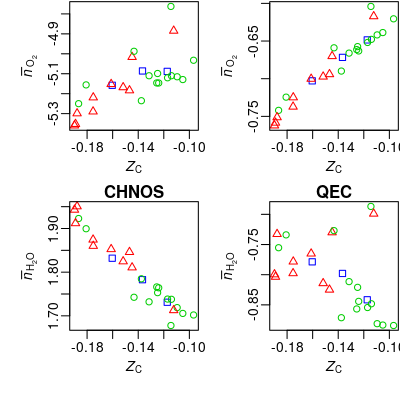

Compositions of proteins projected into different sets of basis species.

```r
layout(matrix(1:4, nrow = 2))
par(mgp = c(1.8, 0.5, 0))
pl <- protein.length(aa)
ZClab <- axis.label("ZC")
nO2lab <- expression(bar(italic(n))[O[2]])
nH2Olab <- expression(bar(italic(n))[H[2]*O])
lapply(c("CHNOS", "QEC"), function(thisbasis) {
  basis(thisbasis)
  pb <- protein.basis(aa)
  nO2 <- pb[, "O2"] / pl
  plot(ZC, nO2, pch = pch, col = col, xlab = ZClab, ylab = nO2lab)
  nH2O <- pb[, "H2O"] / pl
  plot(ZC, nH2O, pch = pch, col = col, xlab = ZClab, ylab = nH2Olab)
  mtext(thisbasis, font = 2)
})
```

By projecting the compositions of proteins into the `QEC` set of basis species, *n*̅<sub>O<sub>2</sub></sub> emerges as a strong indicator of oxidation state, while *n*̅<sub>H<sub>2</sub>O</sub> is a relatively uncorrelated (i.e. independent) compositional variable. These independent variables make it easier to distinguish the effects of oxidation and hydration state in proteomic datasets (Dick, 2017).

Dick JM. 2017. Chemical composition and the potential for proteomic transformation in cancer, hypoxia, and hyperosmotic stress. *PeerJ* **5**: e3421. doi: 10.7717/peerj.3421

## Normalization to residues

As with other systems, a balance must be chosen for calculations of the metastable equilibrium distribution for proteins. Balancing on the number of backbone units (the sequence length) seems a reasonable choice given the polymeric structure of proteins. However, there is an additional consideration: owing to the large size of proteins compared to the basis species, the distribution of *proteins* in metastable equilibrium has many orders of magnitude separation between the activities of the dominant and less-dominant proteins. The metastable coexistence of the *residues* (i.e. per-residue formulas, or residue equivalents) of the same proteins spans a much smaller range of chemical activities. In CHNOSZ, the calculation of metastable equilibrium activities of the residue equivalents is referred to as *normalization*.

Balancing on one of the basis species remains a possibility, using the `balance` argument in `equilibrate()` or `diagram()`.

See the vignette *Equilibrium in CHNOSZ* for other examples using normalization.

To take an example, let’s look at the metastable equilibrium distribution of selected proteins in the ER-to-Golgi location of *S. cerevisiae* (yeast). This example brings in a few other functions we haven’t seen yet: `yeastgfp()`, `unitize()`, and `revisit()`. `yeastgfp()` queries a data file in CHNOSZ for the names and relative abundances of proteins taken from the YeastGFP study of Ghaemmaghami et al. (2003). There are six proteins identified in the ER-to-Golgi location; one has NA abundance, so it is excluded from the comparisons:

Ghaemmaghami S, Huh W-K, Bower K, Howson RW, Belle A, Dephoure N, O’Shea EK, Weissman JS. 2003. Global analysis of protein expression in yeast. *Nature* **425**(6959): 737–741. doi: 10.1038/nature02046

```r
y <- yeastgfp("ER.to.Golgi")
ina <- is.na(y$abundance)
```

Next, we get the amino acid compositions of the proteins and add them to `thermo$protein`:

```r
aa <- yeast.aa(y$protein[!ina])
ip <- add.protein(aa)
```

The YeastGFP study reported absolute abundances of molecules, but the thermodynamic calculations give relative chemical activities of the proteins. In order to make a comparison between them, we use `unitize()` to scale the abundances or activities of proteins (in logarithmic units) such that the total abundance or activity of residue equivalents is unity. To do that, we must have the lengths of the proteins. Here, the first call to `unitize()` generates equal logarithms of activities of proteins for unit total activity of residues; this is used as the reference state for `affinity()`. The second call to `unitize()` scales the logarithms of experimental abundances for unit total activity of residues; this is used for comparison with the theoretical results:

```r
pl <- protein.length(ip)
logact <- unitize(numeric(5), pl)
logabundance <- unitize(log10(y$abundance[!ina]), pl)
```

Now we can load the proteins and calculate their activities in metastable equilibrium as a function of log*f*<sub>O<sub>2</sub></sub>:

The commented line uses `mod.obigt()` to revert the parameters of the methionine sidechain group to those present in older versions of CHNOSZ (Dick et al., 2006). The current database, with parameters set by `data(thermo)` and used here, contains updated group additivity parameters for methionine (LaRowe and Dick, 2012).

```r
par(mfrow = c(1, 3))
basis("CHNOS+")
#mod.obigt("[Met]", G = -35245, H = -59310)
a <- affinity(O2 = c(-80, -73), iprotein = ip, loga.protein = logact)
e <- equilibrate(a)
diagram(e, ylim = c(-5, -2), col = 1:5, lwd = 2)
```

Whoa! The proteins look very non-coexistent in metastable equilibrium. We get a different view by considering per-residue rather than per-protein reactions, through the `normalize` argument for `equilibrate()`:

The normalization step is followed by conversion of activities of residues to activities of proteins; that conversion can be skipped using the `as.residue` argument in `equilibrate()`.

```r
e <- equilibrate(a, normalize = TRUE)
diagram(e, ylim = c(-5, -2.5), col = 1:5, lwd = 2)
abline(h = logabundance, lty = 1:5, col = 1:5)
```

The experimental relative abundances are plotted as thin horizontal lines with the same style and color as the thicker curved lines calculated for metastable equilibrium. With the exception of YNL049C, the overlap between the calculations and experiments looks to be greatest near the middle-left part of the figure. The `revisit()` function (see below) offers some statistical and thermodynamic measures that can quantify this comparison. Here, we plot the information-theoretic free energy Δ*G<sub>inf</sub>* (calculated from the relative entropy or Kullback–Leibler divergence):

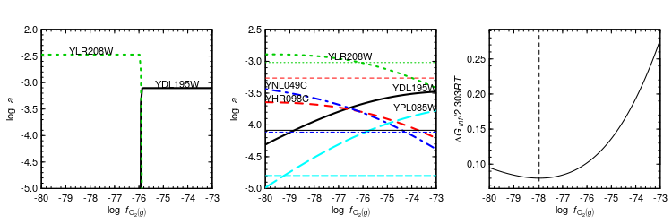

ER-to-Golgi proteins: calculations without and with length normalization, and free energy difference between experimental and calculated abundances in metastable equilibrium with normalization.

```r
revisit(e, "DGinf", logabundance)
```

The minimum free energy difference occurs near log*f*<sub>O<sub>2</sub></sub> = -78. This agrees with the assessment shown in Figure 4 of Dick (2009) (note that the old parameters for the methionine sidechain group were used in that study).

Dick JM. 2009. Calculation of the relative metastabilities of proteins in subcellular compartments of *Saccharomyces cerevisiae*. *BMC Systems Biology* **3**: 75. doi: 10.1186/1752-0509-3-75

## An affinity baseline

Because affinities of proteins often vary strongly with oxygen fugacity and other variables, it can be helpful to express the values as differences from a baseline. The following example compares the affinities for formation of transcription factors involved in embryonic dorsal-ventral patterning with that of the morphogen, Sonic hedgehog (Shh), as a function of log*f*<sub>O<sub>2</sub></sub> and log*a*<sub>H<sub>2</sub>O</sub> (Dick, 2015). We first list the UniProt names of Shh and 10 transcription factors, and get the `iprotein` indices (rownumbers of `thermo$protein`):

Dick JM. 2015. Chemical integration of proteins in signaling and development. *bioRxiv*. doi: 10.1101/015826

```r
pname <- c("SHH", "OLIG2", "NKX22", "FOXA2", "IRX3",
  "PAX6", "NKX62", "DBX1", "DBX2", "NKX61", "PAX7")
ip <- pinfo(pname, "HUMAN")
```

Next, set up the basis species:

```r
basis("CHNOS")
basis("NH3", -7)
```

Now calculate the affinities of formation of the proteins from the basis species. The values chosen for log*f*<sub>O<sub>2</sub></sub> and log*a*<sub>H<sub>2</sub>O</sub> covary, so we are using the transect mode of `affinity()`:

```r
O2 <- seq(-70, -106, length.out = 50)
H2O <- seq(0.5, -5.5, length.out = 50)
a <- affinity(H2O = H2O, O2 = O2, iprotein = ip)
```

We would like to compare the affinities of the proteins on a per-residue scale. R’s `lapply()` could be used here, but to show the operation more clearly we use a `for()` loop:

```r
pl <- protein.length(ip)
for(i in seq_along(a$values)) a$values[[i]] <- a$values[[i]] / pl[i]
```

Then, we calculate the relative affinities, using Shh as the baseline:

```r
a.Shh <- a$values[[1]]
for(i in 1:length(a$values)) a$values[[i]] <- a$values[[i]] - a.Shh
```

Next we use `diagram()` to plot the affinities. We set `balance = 1` to plot the values as they are—without that, `diagram()` divides the values by protein length, which we have already done! For this plot, we highlight and label the proteins with the highest relative affinity at some combination of log*f*<sub>O<sub>2</sub></sub> and log*a*<sub>H<sub>2</sub>O</sub> along the transect. Those proteins are Olig2, Irx3, Nkx6.2, Dbx1, and Shh (numbers 2, 5, 7, 8, 1 in the set we have identified). Here, `adj = 0` makes the labels left-aligned, `dy = 0.1` adds a *y* offset to the labels, and `format.names = FALSE` prevents formatting of the names as if they were chemical formulas (that causes subscripted numbers to appear). The last few lines are used to make a second *x* axis, using a label generated with `axis.label()`:

See `demo(Shh)` for a plot with more interpretive labels and comments.

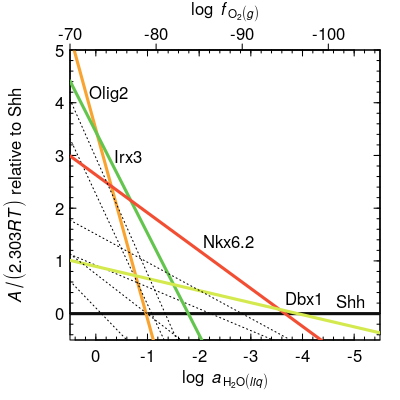

Per-residue affinities for formation of transcription factors relative to Shh.

```r
# line type, width, and color
twc <- lapply(c(3, 1, 1), rep, length(pname))
ihigh <- c(2, 5, 7, 8, 1)
twc[[1]][ihigh] <- 1
twc[[2]][ihigh] <- 3
col <- c("#f9a330", "#63c54e", "#f24e33", "#d4e94e", "#0f0f0f")
twc[[3]][ihigh] <- col
names <- rep("", length(pname))
names[ihigh] <- c("Olig2", "Irx3", "Nkx6.2", "Dbx1", "Shh")
ylab <- substitute(italic(A) / (2.303 * italic(RT)) * " relative to Shh")
diagram(a, balance = 1, ylim = c(-0.5, 5), xlim = c(0.5, -5.5),
  lty = twc[[1]], lwd=twc[[2]], col = twc[[3]], ylab = ylab,
  names = names, adj = 0, dy = 0.1, format.names = FALSE)
par(usr = c(-70, -106, -0.5, 5), tcl = -0.3)
axis(3, at = seq(-70, -106, by = -10))
mtext(axis.label("O2"), line = 1.2)
```

Among these proteins, Olig2 and Shh have the greatest affinities for formation at the extremes of oxidation and hydration state. This thermodynamic description highlights possible links between the chemical compositions of the proteins and their patterns of expression along with chemical changes in developing embryos (Dick, 2015).

## Getting amino acid compositions

In the Rubisco example above, we saw the use of `read.fasta()` to read amino acid sequences from a FASTA file. There are several other methods for inputting amino acid compositions.

R’s `read.csv()` can be used to read amino acid compositions from a CSV file with the same columns that are present in `thermo$protein`. Note the use of `as.is = TRUE` to prevent reading character data as factors. The `nrows` argument can be added to read that number of rows:

```r
file <- system.file("extdata/protein/DS11.csv", package = "CHNOSZ")
aa_bison <- read.csv(file, as.is = TRUE, nrows = 5)
```

`yeast.aa()` retrieves amino acid composition of proteins in *Saccharomyces cerevisiae* from a data file that is included with CHNOSZ:

```r
aa_YML020W <- yeast.aa("YML020W")
```

`read.fasta()` reads a FASTA file and returns the amino acid compositions of the sequences. The `iseq` argument can be used to read those sequences from the file:

```r
file <- system.file("extdata/fasta/EF-Tu.aln", package = "CHNOSZ")
aa_Ef <- read.fasta(file, iseq = 1:2)
```

`seq2aa()` counts the amino acids in a user-supplied sequence and generates a data frame of the amino acid composition:

See also `?count.aa`, which can process both protein and nucleic acid sequences.

```r
aa_PRIO <- seq2aa("PRIO_HUMAN", "
MANLGCWMLVLFVATWSDLGLCKKRPKPGGWNTGGSRYPGQGSPGGNRYPPQGGGGWGQP
HGGGWGQPHGGGWGQPHGGGWGQPHGGGWGQGGGTHSQWNKPSKPKTNMKHMAGAAAAGA
VVGGLGGYMLGSAMSRPIIHFGSDYEDRYYRENMHRYPNQVYYRPMDEYSNQNNFVHDCV
NITIKQHTVTTTTKGENFTETDVKMMERVVEQMCITQYERESQAYYQRGSSMVLFSSPPV
ILLISFLIFLIVG
")
```

`uniprot.aa()` returns the amino acid composition of a single amino acid sequence downloaded from UniProt. To get sequences for many proteins, use R’s `lapply()`, `do.call()`, and `rbind()`:

```r
IDs <- c("ALAT1_HUMAN", "P02452")
aa <- lapply(IDs, uniprot.aa)
## uniprot.aa: trying http://www.uniprot.org/uniprot/ALAT1_HUMAN ... accession P24298 ...
## >sp|P24298|ALAT1_HUMAN Alanine aminotransferase 1 OS=Homo sapiens GN=GPT PE=1 SV=3 (length 496)
## uniprot.aa: trying http://www.uniprot.org/uniprot/P02452 ... accession P02452 ...
## >sp|P02452|CO1A1_HUMAN Collagen alpha-1(I) chain OS=Homo sapiens GN=COL1A1 PE=1 SV=5 (length 1464)
aa_UniProt <- do.call(rbind, aa)
```

```r
aa_UniProt
```

```
##      protein organism ref abbrv chains Ala Cys Asp Glu Phe Gly His Ile Lys Leu
## 1  sp|P24298    HUMAN  NA ALAT1      1  51  10  20  34  21  38   9  18  16  55
## 11 sp|P02452    HUMAN  NA CO1A1      1 139  18  66  75  27 391   9  24  57  48
##    Met Asn Pro Gln Arg Ser Thr Val Trp Tyr
## 1   12  12  33  30  37  25  18  41   1  15
## 11  13  28 278  49  71  60  45  47   6  13
```

These amino acid compositions can be processed using functions such as `protein.length()` and `protein.formula()`:

```r
myaa <- rbind(aa_YML020W, aa_Ef, aa_PRIO)
protein.length(myaa)
```

```
## [1] 664 394 394 253
```

## Adding proteins and using `iprotein`

Once the amino acid compositions have been obtained, use `add.protein()` to add these proteins to `thermo$protein`:

```r
add.protein(myaa)
```

```
## add.protein: added 4 new protein(s) to thermo$protein
```

```
## [1] 512 513 514 515
```

Then, `subcrt()` can be used to calculate the standard thermodynamic properties of any of these proteins:

```r
subcrt("PRIO_HUMAN", T = 25)
```

```
## $species
##            name               formula state ispecies
## 3618 PRIO_HUMAN C1227H1834N352O352S16    aq     3618
##
## $out
## $out$PRIO_HUMAN
##    T P      rho    logK        G         H       S       V      Cp
## 1 25 1 0.997061 5486.45 -7484855 -19116027 8124.78 20084.3 12174.4
```

Or we can add any of these proteins to the species list with `species()` and calculate the affinity:

```r
basis("CHNOS")
```

```r
species("YML020W_Sce")
```

```
##    CO2  H2O NH3 H2S    O2 ispecies logact state        name
## 1 3406 1247 932  13 -3517     3619     -3    aq YML020W_Sce
```

```r
a <- affinity()
```

Or we can calculate the affinities of formation reactions of the proteins without adding them as species:

```r
ip <- add.protein(aa_UniProt)
a <- affinity(iprotein = ip)
```

As shown there, the `iprotein` argument of `affinity()` can be used to calculate the affinities of reactions to form the indicated proteins, bypassing the `species()` step. Let’s see this in action using amino acid compositions deduced from metagenomic sequences in the Bison Pool hot spring in Yellowstone (Dick and Shock, 2011). We read a data file of amino acid compositions produced in that study, taking those labeled “transferase”. Then we add the proteins and get their indices using `add.protein()`, set the basis, calculate the affinities, and make a potential diagram with temperature and activity of dissolved hydrogen as variables:

Dick JM, Shock EL. 2011. Calculation of the relative chemical stabilities of proteins as a function of temperature and redox chemistry in a hot spring. *PLoS ONE* **6**(8): e22782. doi: 10.1371/journal.pone.0022782

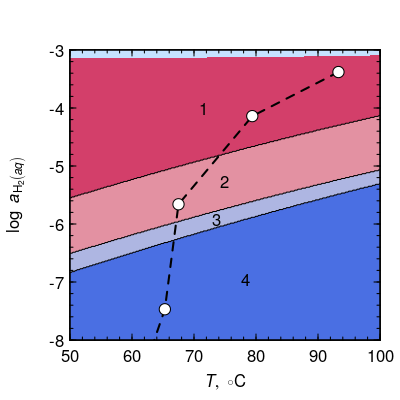

Potential diagram for metagenomically identified sequences of transferases in Bison Pool hot spring. See also the vignette *Hot-spring proteins in CHNOSZ*.

```r
file <- system.file("extdata/protein/DS11.csv", package = "CHNOSZ")
aa <- read.csv(file, as.is = TRUE)
aa <- aa[grep("transferase", aa$protein), ]
ip <- add.protein(aa)
basis(c("HCO3-", "H2O", "NH3", "HS-", "H2", "H+"))
basis(c("HCO3-", "NH3", "HS-", "H+"), c(-3, -4, -7, -7.9))
T <- c(50, 100)
res <- 300
a <- affinity(T = c(T, res), H2 = c(-8, -3, res), iprotein = ip)
fill <- ZC.col(ZC(protein.formula(ip)))
diagram(a, normalize = TRUE, fill = fill, names = 1:5)
```

Site numbers 1–5 correspond to a cooling gradient along the outflow channel of the hot spring. The colors represent the relative *Z*<sub>C</sub> of the proteins (red is more reduced). The points indicate the *T* and log*a*<sub>H<sub>2</sub></sub> that optimize a thermodynamic model for relative abundances of phyla that were estimated by taxonomic classification of metagenomic sequences (Dick and Shock, 2013):

Dick JM, Shock EL. 2013. A metastable equilibrium model for the relative abundances of microbial phyla in a hot spring. *PLoS ONE* **8**(9): e72395. doi: 10.1371/journal.pone.0072395

```r
T <- c(93.3, 79.4, 67.5, 65.3, 57.1)
logaH2 <- c(-3.38, -4.14, -5.66, -7.47, -10.02)
lines(T, logaH2, lty = 2, lwd = 2)
points(T, logaH2, pch = 21, bg = "white", cex = 1.5)
```

# Optimization of chemical activities

**NOTE: This is an experimental feature.**

What are the conditions that minimize the standard deviation of calculated activities of species? What are the conditions that minimize the energetic difference between measured and calculated abundances? These are questions about optimization of chemical activities. `revisit()` provides calculations and plots of an objective function in 1 or 2 dimensions (activities of basis species, *T*, or *P*). `findit()` provides a calculation of an objective function on a higher-dimensional grid.

See `?objective` for more information.

The concentrations of amino acids are affected by high-temperature reactions in hydrothermal vents (smokers). What are the metastable equilibrium states of amino acids under these conditions? Suppose that the major variables are oxygen fugacity, and activities of water (H<sub>2</sub>O) and ammonia (NH<sub>3</sub>). Here we assign the (very large) range of logarithms of chemical activity of the basis species that we will explore:

```r
vars <- list(O2 = c(-50, -25), NH3 = c(-15, 10), H2O = c(-15, 10))
```

Consider the amino acid abundances reported by Fuchida et al. (2014). Here, we identify the amino acids using their one-letter abbreviations. Then, `aminoacids()` is used to produce the full names, which in turn are used to search `thermo$obigt` for their formulas. `makeup()` is used to count the elements in the formulas:

Fuchida S, Mizuno Y, Masuda H, Toki T, Makita H. 2014. Concentrations and distributions of amino acids in black and white smoker fluids at temperatures over 200 °C. *Organic Geochemistry* **66**: 98–106. doi: 10.1016/j.orggeochem.2013.11.008

```r
aa <- c("D", "T", "S", "E", "G", "A", "K", "H")
AA <- aminoacids("", aa)
AA.formula <- do.call(rbind, makeup(info(AA)))
AA
```

```
## [1] "aspartic acid" "threonine"     "serine"        "glutamic acid"
## [5] "glycine"       "alanine"       "lysine"        "histidine"
```

Let’s use the reported concentrations (µM) of amino acids in sample D1441 CW-2. The concentrations are converted to logarithmic values (`loga2`). We then calculate the total C concentration in the measurements; this uses the amino acid formulas calculated above:

Three amino acids (Val, Phe, Arg) with concentrations below the detection limit of 0.01 µM are not included here.

```r
uM <- c(1.10, 0.70, 3.73, 0.39, 3.04, 1.83, 0.27, 0.21)
loga2 <- log10(uM * 1e-6)
nC <- AA.formula[, "C"]
Ctot <- sum(nC * uM * 1e-6)
```

Next, we set the basis, load the species, and assign the temperature and resolution to be used in `affinity()`. Also, we assign the objective function to be the root mean square deviation (RMSD) between experimental and calculated logarithms:

```r
basis("CHNOS")
species(AA)
T <- 270
res <- 64
objective <- "RMSD"
```

Then, we set up the figure, calculate chemical affinities in one dimension, and run `equilibrate()` with the given total carbon activity. `revisit()` is used to plot RMSD and to identify the log*f*<sub>O<sub>2</sub></sub> where it is minimized:

```r
layout(matrix(1:6, nrow = 2))
a <- affinity(O2 = c(vars[[1]], res), T = T)
e <- equilibrate(a, loga.balance = log10(Ctot))
r <- revisit(e, objective, loga2)
d.basis <- describe.basis(ibasis = 1:4)
legend("topleft", d.basis)
```

Now, we write a function that calculates the affinities and metastable equilibrium activities at a single condition and uses `revisit()` to make a scatter plot. The plot includes a 1:1 line (grey), a trend line calculated using R’s `loess.smooth()` (red), and a title with the minimum value of RMSD. The function also adds a legend summarizing the optimal conditions:

```r
ourfun <- function(ibasis = 1:5, x = "bottomright") {
  a <- affinity(T = T)
  e <- equilibrate(a, loga.balance = log10(Ctot))
  revisit(e, objective, loga2, cex = 2.7, pch = 21)
  text(loga2, unlist(e$loga.equil), aa)
  d.basis <- describe.basis(ibasis = ibasis)
  legend(x, d.basis)
}
```

We set the activity of log*f*<sub>O<sub>2</sub></sub> in the basis (where RMSD was minimized the first call to `revisit()`), then use our function to make a scatter plot:

```r
basis("O2", r$xopt)
ourfun(5)
```

In the next pair of plots, let’s use two variables: log*f*<sub>O<sub>2</sub></sub> and log*a*<sub>NH<sub>3</sub></sub>. This time, `revisit()` makes a contour diagram of the objective function, highlighting the location of the minimum (star) as well as the minimum trough following the *x* or *y* axis (dotted blue and green lines). After that, we set the activities of both of the basis species and then use `ourfun()` to make a scatter plot. The legend here shows the two variables that have been optimized; these conditions yield an RMSD that is lower than in the first calculation:

```r
a <- affinity(O2 = c(vars[[1]], res), NH3 = c(vars[[2]], res), T = T)
e <- equilibrate(a, loga.balance = log10(Ctot))
r <- revisit(e, objective, loga2)
basis("O2", r$xopt)
basis("NH3", r$yopt)
ourfun(c(3, 5))
```

Finally, we use `findit()` to optimize three variables. The affinity and equilibrium calculations are integrated into `findit()`, so the function call requires the `loga.balance` and `T` arguments. Other arguments indicate the grid resolution, factor (ratio) by which variable ranges are reduced in each step, and the number of iterations. The result is a series of 2D contour plots of decreasing range, each one constructed for the optimal value of log*a*<sub>H<sub>2</sub>O</sub> from the previous step. While running, `findit()` sets the activities of basis species, so we can immediately call `ourfun()` to make make a scatter plot.

More dimensions require a lower resolution due to limited computational resources.

This side effect (changing the activities of basis species) is why the text for `findit()` is colored red.

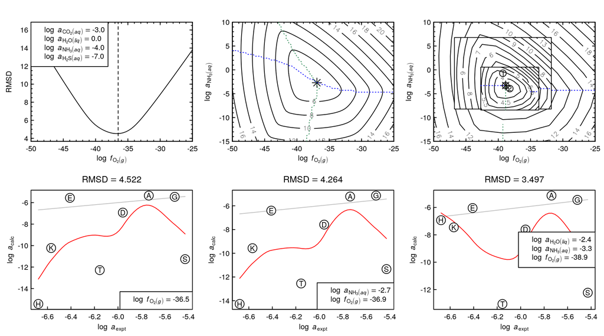

Optimization of a thermodynamic model for relative abundances of amino acids in a 270 °C black smoker fluid using 1, 2, or 3 variables (left to right).

```r
findit(vars[1:3], objective, loga2 = loga2, loga.balance = log10(Ctot),
       T = T, res = 8, niter = 3, rat = 0.6)
ourfun(c(2, 3, 5), "right")
```

The calculation using `findit()`, in which the added variable log*a*<sub>H<sub>2</sub>O</sub> optimizes to ca. -2.4, shows that measured concentrations of 6 amino acids fall within 1–2 log units of the relative abundances in metastable equilibrium. According these calculations, two amino acids, serine and threonine, are very far from metastable equilibrium with the others. There is a danger of using too many, or unrepresentative variables, but in some systems, calculations of this type may provide insight on processes affecting reactions of organic compounds.

# Thermodynamic data

## Viewing data sources: `thermo.refs()`

The database in CHNOSZ lists one or two sources for each entry, and citation information for the sources is listed in `thermo$refs`. You can locate and view the references with `thermo.refs()`. Running the function without any arguments opens a browser window with the complete table of references. Where available, links to the web page for the articles and books are displayed:

See the vignette, *Thermodynamic data in CHNOSZ*, for a more nicely formatted presentation of the sources of thermodynamic data, along with notes and additional comments.

```r
thermo.refs()  ## shows table in a browser
```

A numeric argument to `thermo.refs()` gives one or more species indices for which to get the references:

```r
iATP <- info("ATP-4")
iMgATP <- info("MgATP-2")
thermo.refs(c(iATP, iMgATP))
```

```
##       key                          author year                               citation                                                    note
## 99  LH06a D. E. LaRowe and H. C. Helgeson 2006 Geochim. Cosmochim. Acta 70, 4680-4724        nucleic-acid bases, nucleosides, and nucleotides
## 101 LH06b D. E. LaRowe and H. C. Helgeson 2006           Thermochim. Acta 448, 82-106 Mg-complexed adenosine nucleotides (ATP), NAD, and NADP
##                                           URL
## 99  https://doi.org/10.1016/j.gca.2006.04.010
## 101 https://doi.org/10.1016/j.tca.2006.06.008
```

A character argument gives the source key(s):

```r
thermo.refs(c("HDNB78", "MGN03"))
```

```
##       key                                    author year                 citation                                              note                                   URL
## 8  HDNB78       H. C. Helgeson, J. M. Delany et al. 1978  Am. J. Sci. 278A, 1-229 data for minerals (n = 167) and phase transitions http://www.worldcat.org/oclc/13594862
## 90  MGN03 J. Majzlan, K.-D. Grevel and A. Navrotsky 2003 Am. Mineral. 88, 855-859        goethite, lepidocrocite, and maghemite GHS https://doi.org/10.2138/am-2003-5-614
```

If the argument holds the result of `subcrt()`, references for all species in the reaction are returned:

The exception is H<sub>2</sub>O. With the default settings, thermodynamic properties for H<sub>2</sub>O are derived from SUPCRT92 (Johnson et al., 1992).

```r
substuff <- subcrt(c("C2H5OH", "O2", "CO2", "H2O"), c(-1, -3, 2, 3))
thermo.refs(substuff)
```

```
##      key                                           author year                               citation                      note                                           URL
## 84  PS01                  A. V. Plyasunov and E. L. Shock 2001 Geochim. Cosmochim. Acta 65, 3879-3900   aqueous nonelectrolytes https://doi.org/10.1016/S0016-7037(01)00678-0
## 23 SHS89 E. L. Shock, H. C. Helgeson and D. A. Sverjensky 1989 Geochim. Cosmochim. Acta 53, 2157-2183 inorganic neutral species  https://doi.org/10.1016/0016-7037(89)90341-4
```

The URLs of the references can be copied to a browser, or opened using R’s `browseURL()`:

```r
iFo <- info("forsterite")
ref <- thermo.refs(iFo)
browseURL(ref$URL)  ## opens a link to worldcat.org
```

## Optional data

Thermodynamic properties of minerals in the default database are mostly taken from Helgeson et al. (1978). These are identified by the state `cr`, and `cr2`, `cr3`, etc. for higher-temperature polymorphs. Optionally, thermodynamic properties of minerals can be calculated using the equations and dataset of Berman (1988); these minerals are identified in the database by having the state `cr_Berman`.

Helgeson HC, Delany JM, Nesbitt HW, Bird DK. 1978. Summary and critique of the thermodynamic properties of rock-forming minerals. *American Journal of Science* **278A**: 1–229. Available at http://www.worldcat.org/oclc/13594862.

Berman RG. 1988. Internally-consistent thermodynamic data for minerals in the system Na<sub>2</sub>O–K<sub>2</sub>O–CaO–MgO–FeO–Fe<sub>2</sub>O<sub>3</sub>–Al<sub>2</sub>O<sub>3</sub>–SiO<sub>2</sub>–TiO<sub>2</sub>–H<sub>2</sub>O–CO<sub>2</sub>. *Journal of Petrology* **29**(2): 445–522. doi: 10.1093/petrology/29.2.445

Two other optional datasets can be activated by using `add.obigt()`:

`add.obigt("SUPCRTBL")` – This loads updated thermodynamic parameters for aqueous SiO<sub>2</sub>, aluminum and arsenic species, and minerals, as compiled in the [SUPCRTBL package](http://www.indiana.edu/~hydrogeo/supcrtbl.html) (Zimmer et al., 2016). SUPCRTBL also includes modifications to SUPCRT92 for calculating thermodynamic properties of minerals using the Holland and Powell (2011) dataset, but that is not available in CHNOSZ. Instead, the Berman mineral data can be used with similar results; see `demo(go-IU)`.

Zimmer K, Zhang Y, Lu P, Chen Y, Zhang G, Dalkilic M, Zhu C. 2016. SUPCRTBL: A revised and extended thermodynamic dataset and software package of SUPCRT92. *Computers & Geosciences* **90**: 97–111. doi: 10.1016/j.cageo.2016.02.013

Holland TJB, Powell R. 2011. An improved and extended internally consistent thermodynamic dataset for phases of petrological interest, involving a new equation of state for solids. *Journal of Metamorphic Geology* **29**(3): 333–383. doi: 10.1111/j.1525-1314.2010.00923.x

`add.obigt("DEW")` – These are aqueous species, with modified parameters, that are intended for use with the [Deep Earth Water](http://www.dewcommunity.org/) (DEW) model (Sverjensky et al., 2014). You should also run `water("DEW")` to activate the equations in the model; then, they will be used by `subcrt()` and `affinity()`. Examples are in `demo(DEW)`.

Sverjensky DA, Harrison B, Azzolini D. 2014. Water in the deep Earth: The dielectric constant and the solubilities of quartz and corundum to 60 kb and 1,200 <sup>∘</sup>C. *Geochimica et Cosmochimica Acta* **129**: 125–145. doi: 10.1016/j.gca.2013.12.019

Detailed lists of sources for these Optional Data are in the vignette *Thermodynamic data in CHNOSZ* (look under **Solids** / **Berman**, **Optional Data** / **SUPCRTBL** and **Optional Data** / **DEW**).

## Adding data

You can also use `add.obigt()` to add data from a user-specified file to the database in the current session. The file must be a CSV (comma separated value) file with column headers that match those in the main database. To show the required format, take a look at `BZA10.csv`, a supplemental data file provided in CHNOSZ. Missing values are indicated by `NA`:

R’s `read.csv()` has a useful option: `as.is = TRUE`. This prevents columns with character data from being read as factors (i.e. categorical data). Passing factors to functions that are designed for character data can give unexpected results or errors.

```r
file <- system.file("extdata/thermo/BZA10.csv", package = "CHNOSZ")
read.csv(file, as.is = TRUE)
```

```
##      name abbrv formula state  ref1 ref2      date       G  H     S     Cp
## 1   CdCl+    NA   CdCl+    aq BZA10   NA 03.Jul.10  -52629 NA  7.06  11.12
## 2   CdCl2    NA   CdCl2    aq BZA10   NA 03.Jul.10  -84883 NA 25.72 116.01
## 3  CdCl3-    NA  CdCl3-    aq BZA10   NA 03.Jul.10 -115399 NA 45.15  97.78
## 4 CdCl4-2    NA CdCl4-2    aq BZA10   NA 03.Jul.10 -145583 NA 50.61  42.52
##       V    a1.a    a2.b    a3.c    a4.d    c1.e    c2.f omega.lambda z.T
## 1  2.20  2.2303 -2.3357  6.6681 -2.6824 16.6723 -0.7693       0.4372   1
## 2 42.21  7.5221 10.5852  1.5895 -3.2166 73.7023 20.5956      -0.0495   0
## 3 63.47 10.8045 18.5994 -1.5605 -3.5479 72.0244 16.8832       0.9378  -1
## 4 81.35 13.8329 25.9938 -4.4669 -3.8536 53.6766  5.6267       2.4766  -2
```

The column names with a dot (`.`) refer to different sets of equations for calculating standard thermodynamic properties. Aqueous species use the revised Helgeson-Kirkham-Flowers (HKF) equations (symbols before the dot), and crystalline, gas and liquid species other than H<sub>2</sub>O use a general heat capacity equation. See `?thermo` for details about what’s in the data table, and `?hkf` and `?cgl` for information about the thermodynamic equations.

Another use of `add.obigt()` is to add data from the file `CHNOSZ_aq.csv`, which holds provisional updates that aren’t loaded by default (i.e., using `data(thermo)`). In this mode, only the name of the species is used as the argument. Currently available species are `adenine-old` and `pseudo-H4SiO4` (see `demo(adenine)` and the vignette, *Regressing thermodynamic data*).

## Modifying data

Use `mod.obigt()` to add or modify the database in the current session. The function requires the name of a species and one or more properties to change. Let’s add data for the S<sub>3</sub><sup>-</sup> ion from Pokrovski and Dubessy (2015). Although we could choose anything for the name (e.g. “trisulfur radical anion”), here we make it the same as the formula. The date for the entry is `today()` (i.e. today’s date using the date format inherited from SUPCRT92):

Pokrovski GS, Dubessy J. 2015. Stability and abundance of the trisulfur radical ion in hydrothermal fluids. *Earth and Planetary Science Letters* **411**: 298–309. doi: 10.1016/j.epsl.2014.11.035

```r
mod.obigt("S3-", formula = "S3-", state = "aq", ref1 = "PD15", date = today(),
          G = 13160, H = 10840, S = 28.6, Cp = 62.3, V = 37.7)
```

```
## mod.obigt: added S3-(aq)
```

```
## [1] 3620
```

The function prints a message saying that the species was added, and returns the species index of the new species. Now let’s modify the same species by adding the HKF coefficients:

```r
mod.obigt("S3-", state = "aq", a1 = 2.5, a2 = 19.9, a3 = 9.2, a4 = -3.6,
          c1 = 50.2, c2 = 9.6, omega = 0.8, z = -1)
```

```
## mod.obigt: updated S3-(aq)
```

```
## [1] 3620
```

Let’s define basis species including S<sub>3</sub><sup>-</sup> to automatically balance the reaction of SO<sub>4</sub><sup>-2</sup> and 2 H<sub>2</sub>S:

```r
basis(c("S3-", "O2", "H2O", "H+"), c("aq", "gas", "liq", "aq"))
```

```
##     H O S  Z ispecies logact state
## S3- 0 0 3 -1     3620      0    aq
## O2  0 2 0  0     3316      0   gas
## H2O 2 1 0  0        1      0   liq
## H+  1 0 0  1        3      0    aq
```

```r
subcrt(c("H2S", "SO4-2"), c(-2, -1), T = c(25, 500), P = c(1, 700))
```

```
## $reaction
##      coeff   name formula state ispecies
## 67   -2.00    H2S     H2S    aq       67
## 24   -1.00  SO4-2   SO4-2    aq       24
## 3620  1.00    S3-     S3-    aq     3620
## 3316  0.75 oxygen      O2   gas     3316
## 1     2.50  water     H2O   liq        1
## 3    -1.00     H+      H+    aq        3
##
## $out
##     T   P      rho      logK       G        H        S          V       Cp
## 1  25   1 0.997061 -45.97177 62716.7  75450.1  42.6525  -0.166515  90.6566
## 2 500 700 0.405762  -5.39411 19082.7 154614.4 175.2765 641.393901 714.1609
```

The reaction coefficients are identical to Reaction 4 of Pokrovski and Dubessy (2015), and the calculated values of log*K* match those shown in their Figure 5.

## Cross-checking data entries

`info()` automatically performs some cross-checks of the thermodynamic data. Let’s do this for the new S<sub>3</sub><sup>-</sup> species:

This only checks the parameters for individual species, not the internal consistency of the database itself.

```r
iS3 <- info("S3-")
info(iS3)
```

```
## checkGHS: G of S3- aq (3620) differs by 661 cal mol-1 from tabulated value
```

```
##      name abbrv formula state ref1 ref2      date     G     H    S   Cp    V
## 3620  S3-  <NA>     S3-    aq PD15 <NA> 11.May.19 13160 10840 28.6 62.3 37.7
##        a1   a2  a3     a4   c1    c2 omega  Z
## 3620 0.25 1990 9.2 -36000 50.2 96000 80000 -1
```

There `checkGHS()` calculated the value of Δ*G*°<sub>*f*</sub> from those of Δ*H*°<sub>*f*</sub> and *S*° and from the entropy of the elements (Cox et al., 1989) in the chemical formula of the species. If the difference between the entered and calculated values of Δ*G*°<sub>*f*</sub> is greater than 100 cal mol<sup>-1</sup>, `checkGHS()` prints a message. The calculated value of Δ*G*°<sub>*f*</sub> was found to be 661 cal mol<sup>-1</sup> higher than the entered value. After checking for any typographical errors in the entries for Δ*G*°<sub>*f*</sub>, Δ*H*°<sub>*f*</sub>, *S*°, and the chemical formula, the source should be consulted for clarification.

Cox JD, Wagman DD, Medvedev VA, editors. 1989. *CODATA Key Values for Thermodynamics*. New York: Hemisphere Publishing Corporation. Available at http://www.worldcat.org/oclc/18559968.

Some species in the main and secondary databases are known to have inconsistent entries. For example, the entry for cyclohexane has *C*<sub>*P*</sub>° and *V*° that differ from those calculated from the HKF parameters. `checkEOS()` is a function that cross-checks these parameters and reports the differences (greater than 1 cm<sup>3</sup> mol<sup>-1</sup> or 1 cal K<sup>-1</sup> mol<sup>-1</sup>) when `info()` is run:

```r
info(info("cyclohexane"))
## checkEOS: Cp of cyclohexane aq (1762) differs by 9.35 cal K-1 mol-1 from tabulated value
## checkEOS: V of cyclohexane aq (1762) differs by 6.64 cm3 mol-1 from tabulated value
```

The species with detected inconsistencies in OBIGT are listed in the file `obigt_check.csv`.

```r
file <- system.file("extdata/thermo/obigt_check.csv", package = "CHNOSZ")
dat <- read.csv(file, as.is = TRUE)
nrow(dat)
```

```
## [1] 275
```

Without additional information, there is often no clear strategy for “fixing” these entries, and they are provided as is.

See the [Numerical Tools from GEOPIG](http://geopig.asu.edu/?q=tools) for SUPCRT updates (slop files), including corrections that have not yet been ported to CHNOSZ.

## Water: SUPCRT92 or IAPWS-95 or DEW

For calculations of the thermodynamic and dielectric properties of liquid and supercritical H<sub>2</sub>O, CHNOSZ uses a Fortran subroutine (`H2O92`) from SUPCRT92 (Johnson et al., 1992). Alternatively, the IAPWS-95 formulation for thermodynamic properties (Wagner and Pruß, 2002) can be utilized. In part because of intrinsic thermodynamic differences between SUPCRT92 and IAPWS-95, as well as different equations used in CHNOSZ for calculating the dielectric constant when the IAPWS-95 option is active, this option could introduce inconsistencies with the data for aqueous species in the database and is not recommended for general use in CHNOSZ. However, the IAPWS-95 equations are useful for other applications, and may be extrapolated to a greater range of *T* and *P* than SUPCRT. See `?water` for more information, as well as the last example in `?subcrt`, where uncommenting the line for the `IAPWS95` option allows extrapolation to lower temperatures for supercooled water.

Wagner W, Pruß A. 2002. The IAPWS formulation 1995 for the thermodynamic properties of ordinary water substance for general and scientific use. *Journal of Physical and Chemical Reference Data* **31**(2): 387–535. doi: 10.1063/1.1461829

More recently (late 2017), an implementation of the [Deep Earth Water](http://www.dewcommunity.org/) (DEW) model was added; see Optional data for more information.

# Messages and errors

As you get started writing your own code and functions that use CHNOSZ, it is not uncommon to encounter problems. For example, mixing data types can cause problems (the important difference between factor and character was mentioned above).

Some functions in CHNOSZ perform “sanity checks” on the arguments and will report errors if an inconsistency is detected. For example, unequal lengths of variables in the transect mode of `affinity()` (when the variables have more than 3 values) cause an error:

```r
basis("CHNOS")
aa <- c("D", "T", "S", "E", "G", "A", "K", "H")
species(aminoacids("", aa))
a <- affinity(O2 = seq(-80, -50), T = seq(0, 100))
```

```
## Error in energy(what = "A", vars = c("O2", "T"), vals = list(-80:-50, : variables define a transect but their lengths are not all equal
```

In normal operation, without errors, many functions print informative messages. Checking these can help you decide if the system and calculations have the desired configuration. Here, we fix the condition that caused the error above:

To reduce clutter, messages have not been shown in the output of most of the examples in this vignette.

```r
a <- affinity(O2 = seq(-80, -50, length.out = 101), T = seq(0, 100))
```

```
## energy.args: pressure is Psat
```

```
## energy.args: variable 1 is log_f(O2) at 101 values from -80 to -50
```

```
## energy.args: variable 2 is T at 101 values from 273.15 to 373.15 K
```

```
## subcrt: 13 species at 101 values of T and P (wet)
```

```r
e <- equilibrate(a)
```

```
## balance: from moles of CO2 in formation reactions
```

```
## equilibrate: n.balance is 4 4 3 5 2 3 6 6
```

```
## equilibrate: loga.balance is -1.48148606012211
```

```
## equilibrate: using reaction method
```

```r
#diagram(e, alpha=TRUE, legend.x=NA)
```

The messages give some useful information, such as the variables and their ranges, the “wetness” of the reactions (i.e. whether they contain water and/or aqueous species), the balanced basis species and balance coefficients, the logarithm of total activity of the balanced basis species, and the equilibration method. The commented call to `diagram()` would produce a diagram that, in this case, doesn’t result in any messages.

Here is another example, with the results hidden, but where the messages show the species in the reaction and the other states that are available for the same compounds in the database. The number of *T* and *P* values comes from the default arguments for `subcrt()`:

```r
subcrt(c("C2H5OH", "O2", "CO2", "H2O"), c(-1, -3, 2, 3))
```

```
## info.character: found C2H5OH(aq), also available in liq, gas
```

```
## info.character: found O2(aq), also available in gas
```

```
## info.character: found CO2(aq), also available in gas
```

```
## info.character: found H2O(liq), also available in cr, aq
```

```
## subcrt: 4 species at 15 values of T and P (wet)
```

You may occasionally encounter programming bugs or limits of the algorithms. The following setup breaks the reaction-matrix calculation for equilibration. Here, C<sub>5</sub>H<sub>9</sub>NO<sub>4</sub> (glutamic acid) is identified as the balance (the only basis species present in all the formation reactions of species). Both a warning and an error are generated due to missing values in a computation within `equil.reaction()`:

```r
basis("QEC")
species(aminoacids("", aa))
a <- affinity()
```

```
## energy.args: temperature is 25 C
```

```
## energy.args: pressure is Psat
```

```
## subcrt: 13 species at 298.15 K and 1 bar (wet)
```

```r
e <- equilibrate(a)
```

```
## balance: from moles of C5H9NO4 in formation reactions
```

```
## equilibrate: n.balance is 0.6 0.6 0.2 1 -0.2 0.2 0.4 -0.6
```

```
## equilibrate: loga.balance is -2.65757731917779
```

```
## equilibrate: using reaction method
```

```
## Error in while (logadiff.min > 0 | logadiff.max < 0) {: missing value where TRUE/FALSE needed
```

```r
## Warning in logafun(logactfun(Abar, i)): NaNs produced
```

This is a case where further development and testing are needed.

If you have problems, be sure to read the help pages, examples, and the source code of the functions. Another resource is the tests that are included with the package. Use R’s `system.file()` to find where these tests are installed on your computer:

```r
system.file("tests/testthat/", package = "CHNOSZ")
```

To run the tests, install and load the [**testthat**](https://cran.r-project.org/package=testthat) package followed by:

```r
test_package("CHNOSZ")
```

Reading and running these tests can be useful for understanding some of the error conditions and other limitations of the functions.

# Functions outside the main workflow

Some functions in CHNOSZ lie outside the main workflow described above.

## Regressing thermodynamic data

`EOSregress()` and related functions can be used to regress “equation of state” parameters (e.g. coefficients in the HKF equations) from heat capacity and volumetric data. See `?EOSregress` and the vignette, *Regressing thermodynamic data*.

## Gibbs energy minimization

`wjd()` implements a Gibbs energy minimization using the method of steepest descent described by White et al. (1958). See `?wjd` as well as the vignette, *Winding journey down (in Gibbs energy)*.

White WB, Johnson SM, Dantzig GB. 1958. Chemical equilibrium in complex mixtures. *Journal of Chemical Physics* **28**(5): 751–755. doi: 10.1063/1.1744264

## Group additivity and EQ3/6 output

`RH2obigt()` implements a group additivity calculation of standard molal thermodynamic properties and equations of state parameters of crystalline and liquid organic molecules from Richard and Helgeson (1998).

Richard L, Helgeson HC. 1998. Calculation of the thermodynamic properties at elevated temperatures and pressures of saturated and aromatic high molecular weight solid and liquid hydrocarbons in kerogen, bitumen, petroleum, and other organic matter of biogeochemical interest. *Geochimica et Cosmochimica Acta* **62**(23-24): 3591–3636. doi: 10.1016/S0016-7037(97)00345-1

`eqdata()` reads data, including concentrations of aqueous species, numbers of moles of solid phases, and mineral saturation states (affinities), from an EQ6 output file (Wolery, 1992).

Wolery TJ. 1992. Eq3/6, A Software Package for Geochemical Modeling of Aqueous Systems: Package Overview and Installation Guide (Version 7.0). Lawrence Livermore National Laboratory. Report No.: UCRL-MA-110662 PT I. doi: 10.2172/138894

## NCBI taxonomy files

Some functions are available (see `?taxonomy`) to read data from NCBI taxonomy files, traverse taxonomic ranks, and get scientific names of taxonomic nodes.

# Citation and contact information

If you use CHNOSZ for publications, please consider citing the following paper:

```r
cref <- citation("CHNOSZ")
print(cref, style = "html")
```

Dick JM (2008). “Calculation of the relative metastabilities of proteins using the CHNOSZ software package.” *Geochemical Transactions*, **9**(10). doi: 10.1186/1467-4866-9-10.

If you have found a bug or have questions that aren’t answered in the documentation please contact the maintainer:

```r
maintainer("CHNOSZ")
```

```
## [1] "Jeffrey Dick <j3ffdick@gmail.com>"
```

Thank you for reading, and have fun!

> “As any practitioner knows, the effort of research is so tedious and time consuming that when the work stops being fun, there’s no sense in continuing. The best scientists live a life of keen amusement.”

> “The real fun of life is this perpetual testing to realize how far out you can go with any potentialities.”

# Document history

- 2010-09-30 Initial version.
- 2011-08-15 Add `browse.refs()`; modifying database hint changed to `help(thermo)`.

  `browse.refs()` was renamed to `thermo.refs()` in 2017.
- 2012-06-16 Add “More activity diagrams”.
- 2015-05-14 Add warning about internal consistency of thermodynamic data.
- 2017-02-15 Completely rewritten; switch from Sweave to knitr (Tufte style).

View the R Markdown source of this document [on R-Forge](https://r-forge.r-project.org/scm/viewvc.php/pkg/CHNOSZ/vignettes/anintro.Rmd?view=markup&root=chnosz) or in R:

```r
file.edit(system.file("doc/anintro.Rmd", package = "CHNOSZ"))
```

```r
   ######    ##   ##    ##   ##    ######     #####  #####
 ##         ##===##    ## \\##   ##    ##     \\       //
 ######    ##   ##    ##   ##    ######    #####      #####
```